# BF528 RNAseq Project

## MultiQC Analysis

We performed quality control analysis of the RNAseq reads using FastQC, STAR, and MultiQC to evaluate the base quality scores, adapter contamination, sequence duplication, and alignment statistics. The overall sequencing quality appears to be good, but a few metrics are worth noting. The FastQC per sequence quality scores are high with all samples having phred scores above 30 with the majority base distribution above 35. Looking at the phred quality scores based on position there is a slight decrease in quality at the 3’ ends of the samples. However, the lowest score is remains above 25 so this is not a reason for concern. Adapter contamination is minimal, and no significant overrepresentation of specific sequences was detected. The STAR alignment results show a high proportion of uniquely mapped reads indicating successful alignment to the reference genome acrosss all samples (>90% for all samples). One potential concern is the proportion of duplicate reads. A higher proportion of duplicate reads in an RNA seq experiment is expected at about 10-40% but in this case the duplicate reads proportion across all samples is around 75%. The consistency of this duplication rate across samples suggests a systematic factor rather than an isolated technical artifact. This should be considered when interpreting expression levels, as it may reflect high expression of certain transcripts or potential library preparation effects.

## Inspecting the counts data

Read in data, create metadata

```r
## Read the CSV file
countsdata <- read_csv('/projectnb/bf528/students/spatra/project-1-sofpatra/results/counts_matrix.csv')
#Inspect countsdata
head(countsdata)
```

| gene | control_rep2 | exp_rep2 | control_rep3 | exp_rep3 | control_rep1 | exp_rep1 |
| --- | --- | --- | --- | --- | --- | --- |
| ENSG00000290825.1 | 0 | 3 | 0 | 1 | 0 | 2 |
| ENSG00000223972.6 | 0 | 0 | 0 | 0 | 0 | 0 |
| ENSG00000227232.6 | 146 | 200 | 220 | 212 | 150 | 164 |
| ENSG00000278267.1 | 0 | 0 | 2 | 0 | 0 | 0 |
| ENSG00000243485.5 | 1 | 4 | 2 | 1 | 2 | 4 |
| ENSG00000284332.1 | 0 | 0 | 0 | 0 | 0 | 0 |

Get metadata from the column names

```r
sample_names <- colnames(countsdata[,-1])

#create metadata dataframe
metadata <- data.frame(
  Sample = sample_names,
  Condition = ifelse(grepl("^co", sample_names), "Control", "Experimental"),
  Replicate = as.integer(sub(".*_rep", "", sample_names))
)
```

## Filtering the counts data

```r
#filter counts based on row sums greater than 10
filtered_counts <- countsdata[rowSums(countsdata[-1]) >= 10, ]

#get number of genes before filtering
before_filtering <-nrow(countsdata)

#get number of genes after filtering
after_filtering <- nrow(filtered_counts)

#create summary table
filter_summary <- data.frame(
  "Stage" = c("Before Filtering", "After Filtering"),
  "Number of Genes" = c(before_filtering, after_filtering)
)

kable(filter_summary, col.names = c("Stage", "Number of Genes"), caption = "Effect of Filtering on Gene Counts")
```

Effect of Filtering on Gene Counts

| Stage | Number of Genes |
| --- | --- |
| Before Filtering | 63241 |
| After Filtering | 27723 |

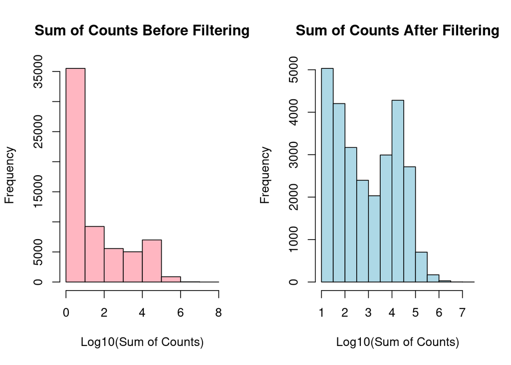

```r
#plot count distributions before and after filtering
prefilter_sums <- rowSums(countsdata[-1])
postfilter_sums <- rowSums(filtered_counts[-1])

#show two plots side by side
par(mfrow = c(1,2))

#create histograms
hist(log10(prefilter_sums +1), main = "Sum of Counts Before Filtering", xlab = "Log10(Sum of Counts)", col = "lightpink", breaks = 10)
hist(log10(postfilter_sums +1), main = "Sum of Counts After Filtering", xlab = "Log10(Sum of Counts)", col = "lightblue", breaks = 10)
```

### Running DEseq2 analysis

```r
#create count matrix
count_mat <- as.matrix(filtered_counts[-1])
row.names(count_mat) <- filtered_counts$gene

design <- formula(~Condition)

#create DeSeq object
dds <- DESeqDataSetFromMatrix(
  countData=count_mat,
  colData=metadata,
  design=design
)
#run DESeq
dds <- DESeq(dds)
resultsNames(dds)
```

```
## [1] "Intercept"                         "Condition_Experimental_vs_Control"
```

```r
#create results tibble
res <- results(dds, name="Condition_Experimental_vs_Control")
exp_vs_control_de <- as_tibble(res) %>%
  mutate(gene=rownames(res)) %>%
  relocate(gene) %>%
  arrange(padj)

#get gene symbols from mapping file
id_mapping <- read_delim('/projectnb/bf528/students/spatra/project-1-sofpatra/results/id_to_symbol.txt')
colnames(id_mapping) <- c("gene", "Symbol")

mapped_results <- exp_vs_control_de %>%
  left_join(id_mapping) %>%
  relocate("Symbol")
#save results csv
write.csv(mapped_results, "/projectnb/bf528/students/spatra/project-1-sofpatra/results/deseq_results.csv", row.names = FALSE)
```

Create table with top 10 significant genes

```r
top10 <- mapped_results[1:10,]
top10$pvalue <- formatC(top10$pvalue, format = "e", digits = 2)
top10$padj <- formatC(top10$padj, format = "e", digits = 2)
kable(top10, caption = "Top ten significant genes.")
```

Top ten significant genes.

| Symbol | gene | baseMean | log2FoldChange | lfcSE | stat | pvalue | padj |
| --- | --- | --- | --- | --- | --- | --- | --- |
| RPS4Y1 | ENSG00000129824.16 | 10667.8495 | -8.774877 | 0.1462801 | -59.98682 | 0.00e+00 | 0.00e+00 |
| ENSG00000289575 | ENSG00000289575.1 | 729.9707 | 3.696955 | 0.1281648 | 28.84532 | 5.80e-183 | 6.01e-179 |
| PNPO | ENSG00000108439.11 | 604.0024 | -4.157958 | 0.1446248 | -28.74996 | 9.07e-182 | 6.27e-178 |
| PCDHGA10 | ENSG00000253846.3 | 495.6879 | 4.479678 | 0.1964036 | 22.80854 | 3.77e-115 | 1.96e-111 |
| YPEL3-DT | ENSG00000250616.4 | 524.3819 | -2.421289 | 0.1201153 | -20.15804 | 2.29e-90 | 9.49e-87 |
| LINC02506 | ENSG00000251129.3 | 1299.7735 | -1.715787 | 0.1023816 | -16.75875 | 4.89e-63 | 1.69e-59 |
| ENSG00000289456 | ENSG00000289456.1 | 383.0923 | -2.134954 | 0.1451269 | -14.71095 | 5.48e-49 | 1.62e-45 |
| ENSG00000286339 | ENSG00000286339.1 | 905.9050 | -1.717348 | 0.1172179 | -14.65090 | 1.33e-48 | 3.45e-45 |
| ENSG00000282914 | ENSG00000282914.1 | 120.8633 | 3.757762 | 0.2652285 | 14.16802 | 1.45e-45 | 3.33e-42 |
| SVIL-AS1 | ENSG00000291093.1 | 152.6023 | 2.881198 | 0.2064400 | 13.95659 | 2.87e-44 | 5.95e-41 |

### Extracting genes with a specified significance level

```r
#Choose an appropriate padj threshold and report the number of significant genes at this threshold.
padj_threshold = 0.05

filtered_results <- mapped_results %>%
  filter(padj <= padj_threshold)

num_genes = nrow(filtered_results)

gene_list <- filtered_results$Symbol
#save gene list to paste into DAVID
write.csv(gene_list, "/projectnb/bf528/students/spatra/project-1-sofpatra/results/significant_genes.txt", row.names = FALSE)

sprintf("There are % s significant genes at the padj threshold of % s", num_genes, padj_threshold)
```

```
## [1] "There are 1173 significant genes at the padj threshold of 0.05"
```

### Enrichment analysis using enrichR

```r
dbs_all <- listEnrichrDbs()
dbs <- c("Reactome_Pathways_2024","GO_Biological_Process_2021")
enriched <- enrichr(gene_list, dbs)
```

```
## Uploading data to Enrichr... Done.
##   Querying Reactome_Pathways_2024... Done.
##   Querying GO_Biological_Process_2021... Done.
## Parsing results... Done.
```

```r
head(enriched$GO_Biological_Process_2021)  # Check results for GO BP
```

|  | Term | Overlap | P.value | Adjusted.P.value | Old.P.value | Old.Adjusted.P.value | Odds.Ratio | Combined.Score | Genes |
| --- | --- | --- | --- | --- | --- | --- | --- | --- | --- |
| 1 | extracellular structure organization (GO:0043062) | 39/216 | 2.922510e-10 | 6.552630e-07 | 0 | 0 | 3.623741 | 79.55346 | COL17A1;LAMA4;SERPINE1;TNC;PDGFA;NID2;THBS1;ADAMTS16;ADAMTSL1;VTN;ADAMTS5;ADAMTS2;ADAMTS18;SPOCK2;KDR;SPP1;ADAMTS8;ADAMTS9;FGB;POSTN;COL24A1;LAMB3;MMP1;LAMB2;ITGA1;MMP3;MMP10;MMP12;MMP11;MMP14;VCAN;CO… |
| 2 | external encapsulating structure organization (GO:0045229) | 39/217 | 3.365501e-10 | 6.552630e-07 | 0 | 0 | 3.603189 | 78.59376 | COL17A1;LAMA4;SERPINE1;TNC;PDGFA;NID2;THBS1;ADAMTS16;ADAMTSL1;VTN;ADAMTS5;ADAMTS2;ADAMTS18;SPOCK2;KDR;SPP1;ADAMTS8;ADAMTS9;FGB;POSTN;COL24A1;LAMB3;MMP1;LAMB2;ITGA1;MMP3;MMP10;MMP12;MMP11;MMP14;VCAN;CO… |
| 3 | extracellular matrix organization (GO:0030198) | 47/300 | 6.703344e-10 | 8.700941e-07 | 0 | 0 | 3.064392 | 64.72991 | COL17A1;LAMA4;SERPINE1;TNC;HTRA1;PDGFA;NID2;THBS1;ADAMTS16;ADAMTSL1;VTN;ADAMTS5;ADAMTS2;ADAMTS18;SPOCK2;KDR;TIMP2;SPP1;CYP1B1;QSOX1;ADAMTS8;ADAMTS9;GPM6B;FGB;POSTN;TGFB2;COL24A1;LAMB3;MMP1;LAMB2;SERPI… |
| 4 | regulation of cell migration (GO:0030334) | 55/408 | 6.841655e-09 | 6.660351e-06 | 0 | 0 | 2.574584 | 48.40279 | RET;PTPRT;PTPRU;IFITM1;CSF1;PLXND1;CITED2;SERPINE1;LDB2;CLDN1;AMOT;DOCK10;SHH;DACH1;FGF9;PLAU;DPYSL3;KDR;CYP1B1;CTSH;PHACTR1;PLXNC1;LIMCH1;LMO4;HGF;F3;ADRA2A;CLDN4;MMP14;SFRP1;SFRP2;CEACAM6;CDH13;SGK1… |
| 5 | regulation of cell population proliferation (GO:0042127) | 83/764 | 3.819293e-08 | 2.974465e-05 | 0 | 0 | 2.029016 | 34.65684 | PTPRU;TENM1;BTG2;CDKN1A;IFITM1;CSF1;BNC1;AREG;CLU;SHH;HMGN5;FGF9;KDR;CYP1B1;CTSH;ADAMTS8;IGFBP3;ITGA1;MATK;EMP2;LIFR;GAB2;AXIN2;SSTR1;SSTR2;CBFA2T3;PGF;ADRA2A;WDR77;RUNX1;KAT2B;SFRP1;SFRP2;CEACAM6;SFR… |
| 6 | positive regulation of cellular process (GO:0048522) | 71/625 | 6.677144e-08 | 4.153214e-05 | 0 | 0 | 2.125088 | 35.11068 | RYR2;SLC44A4;CSF1;BNC1;CITED2;AREG;SHH;HMGN5;FGF9;KDR;CTSH;CAMK1D;TRPC3;SERPINF2;NSMCE1;MATK;EMP2;LIFR;GAB2;AXIN2;DUSP26;ISL1;PGF;ADRA2A;WDR77;MMP14;SFRP1;SFRP2;CEACAM6;MAP1A;CD47;GAS6;COLEC12;LRP1;HP… |

```r
enriched$Reactome_Pathways_2024  # Check KEGG results
```

| Term | Overlap | P.value | Adjusted.P.value | Old.P.value | Old.Adjusted.P.value | Odds.Ratio | Combined.Score | Genes |
| --- | --- | --- | --- | --- | --- | --- | --- | --- |
| Extracellular Matrix Organization | 47/300 | 6.703344e-10 | 9.491936e-07 | 0 | 0 | 3.064392e+00 | 6.472991e+01 | COL17A1;LAMA4;NRXN1;SERPINE1;TNC;HTRA1;PDGFA;LRP4;NID2;THBS1;ADAMTS16;VTN;ADAMTS5;CAPN8;ADAMTS2;CAPN6;ADAMTS18;KDR;TIMP2;SPP1;EMILIN1;ADAMTS8;ADAMTS9;FGB;TGFB2;COL24A1;LAMB3;MMP1;LAMB2;ITGA1;MMP3;MMP1… |
| Regulation of IGF Transport and Uptake by Insulin-like Growth Factor Binding Proteins (IGFBPs) | 26/124 | 1.103795e-08 | 7.814872e-06 | 0 | 0 | 4.332100e+00 | 7.937241e+01 | CSF1;KLK1;TNC;AFP;C3;STC2;PENK;GPC3;SPP1;QSOX1;APOE;IGFBP6;APOL1;MMP1;GOLM1;LAMB2;IGFBP3;KLK13;F2;F5;BMP4;VCAN;MELTF;FAM20A;GAS6;FBN1 |
| Neuronal System | 54/411 | 2.288791e-08 | 1.080309e-05 | 0 | 0 | 2.496677e+00 | 4.392318e+01 | GABRB3;ACHE;GABRB2;KCNC3;GRIK5;ABAT;KIF17;SLC6A4;LRRTM3;DLGAP1;CHRNB2;KCNH5;KCNH6;KCND3;CACNA2D3;KCNK16;KCNK17;GJD2;SLC5A7;ARHGEF9;NLGN3;CHRNA1;EPB41;MAOA;STXBP1;NRXN1;CACNA1B;CACNA1A;SLC1A3;ADCY8;PPM… |
| Degradation of the Extracellular Matrix | 25/140 | 5.541680e-07 | 1.802951e-04 | 0 | 0 | 3.543403e+00 | 5.104554e+01 | COL17A1;HTRA1;ADAMTS16;ADAMTS5;CAPN8;CAPN6;ADAMTS18;TIMP2;SPP1;ADAMTS8;ADAMTS9;LAMB3;MMP1;MMP3;MMP10;MMP12;MMP11;MMP14;COL2A1;MMP16;COL6A2;COL9A3;COL6A6;COL9A2;FBN1 |
| Regulation of Gene Expression in Endocrine-Committed (NEUROG3+) Progenitor Cells | 5/5 | 6.883485e-07 | 1.802951e-04 | 0 | 0 | 9.413500e+04 | 1.335679e+06 | NEUROD1;PAX4;INSM1;NEUROG3;NKX2-2 |
| TP53 Regulates Transcription of Cell Death Genes | 13/44 | 8.563858e-07 | 1.802951e-04 | 0 | 0 | 6.794994e+00 | 9.492977e+01 | STEAP3;IGFBP3;TNFRSF10C;TNFRSF10B;TNFRSF10A;TRIAP1;NDRG1;TNFRSF10D;PIDD1;TP53I3;BAX;FAS;TP63 |
| Post-translational Protein Phosphorylation | 21/107 | 8.912891e-07 | 1.802951e-04 | 0 | 0 | 3.972475e+00 | 5.533894e+01 | CSF1;GOLM1;LAMB2;IGFBP3;TNC;AFP;F5;C3;BMP4;VCAN;STC2;PENK;GPC3;SPP1;QSOX1;APOE;MELTF;FAM20A;GAS6;APOL1;FBN1 |
| TP53 Regulates Transcription of Death Receptors and Ligands | 7/12 | 1.431139e-06 | 2.533116e-04 | 0 | 0 | 2.259931e+01 | 3.041199e+02 | IGFBP3;TNFRSF10C;FAS;TNFRSF10B;TNFRSF10A;TP63;TNFRSF10D |
| Regulation of Beta-Cell Development | 12/42 | 3.350883e-06 | 5.272057e-04 | 0 | 0 | 6.476141e+00 | 8.164009e+01 | NEUROD1;KAT2B;ONECUT1;AKT3;PAX4;SLC2A2;PAX6;INSM1;NKX6-1;GCK;NKX2-2;NEUROG3 |
| Neurofascin Interactions | 5/7 | 1.308364e-05 | 1.852643e-03 | 0 | 0 | 4.029324e+01 | 4.530631e+02 | CNTNAP1;NFASC;CNTN1;DCX;NRCAM |

[output cut: 1406 more lines]

### RNAseq Quality Control Plots

#### PCA

```
## using ntop=500 top features by variance
```

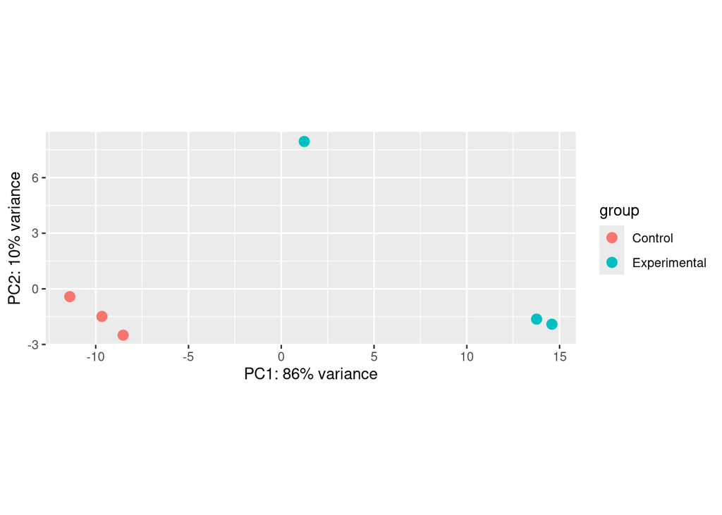

```r
vsd <- vst(dds)  # Use Variance Stabilizing Transformation (or rlog)
plotPCA(vsd, intgroup="Condition")
```

#### Sample-to-sample Distance

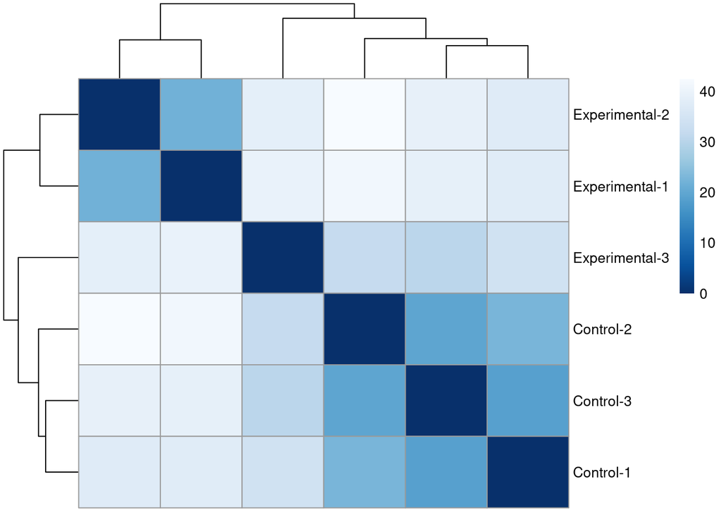

```r
sampleDists <- dist(t(assay(vsd)))
sampleDistMatrix <- as.matrix(sampleDists)
rownames(sampleDistMatrix) <- paste(vsd$Condition, vsd$Replicate, sep="-")
colnames(sampleDistMatrix) <-NULL
colors <- colorRampPalette(rev(brewer.pal(9, "Blues")))(255)
pheatmap(sampleDistMatrix,
         clustering_distance_rows = sampleDists,
         clustering_distance_cols = sampleDists,
         col=colors)
```

In the PCA plot, PC1 explains 86% of the variance, while PC2 accounts for 10%, together capturing the majority of the variation in the dataset. The samples cluster primarily by condition, with the controls forming a tight group and two of the experimental samples also clustering closely together. However, one experimental sample appears positioned between the control and experimental groups, suggesting it may exhibit intermediate characteristics. This sample warrants further investigation to determine whether its placement is due to biological variability, technical factors, or potential sample misclassification.

This clustering pattern is further reinforced by the sample-to-sample distance analysis. The heatmap highlights the close relationship between the two experimental replicates and the strong clustering of the controls. The third experimental replicate appears potentially more similar to the control group than to its experimental counterparts. This could indicate batch effects, an issue with sample preparation, or true biological variation within the experimental condition. Further analysis would help clarify the nature of this outlier and its impact on the overall conclusions of the experiment. It might also be worthwhile to remove this replicate from the analysis altogether.

FGSEA

```r
labeled_res <- mapped_results %>%
  arrange(desc(log2FoldChange)) %>%
  drop_na()

#create tibble with log2 fold change and names

log2fc_tibble <- tibble(Symbol = labeled_res$Symbol, log2FoldChange = labeled_res$log2FoldChange)


# Get unique rows based on both Symbol and log2FoldChange
unique_log2fc_tibble <- log2fc_tibble %>%
  group_by(Symbol) %>%
  summarize(log2FoldChange = mean(log2FoldChange, na.rm = TRUE)) %>%
  ungroup()

# Convert to a named vector
rnk_list <- setNames(unique_log2fc_tibble$log2FoldChange, unique_log2fc_tibble$Symbol)
rnk_list <- na.omit(setNames(unique_log2fc_tibble$log2FoldChange, unique_log2fc_tibble$Symbol))


# Get C2 canonical pathways for human
c2_pathways <- msigdbr(species = "Homo sapiens", category = "C2")

# Convert to a list of gene sets (like GMT format)
pathways <- split(c2_pathways$gene_symbol, c2_pathways$gs_name)




fgseaRes <- tibble(fgsea(pathways, rnk_list, 15, 500))
```

```r
#filter fgsea results
filtered_fgsea <- fgseaRes %>%
  filter(pval <= 0.05) %>%
  arrange(padj)

filtered_fgsea
```

| pathway | pval | padj | log2err | ES | NES | size | leadingEdge |
| --- | --- | --- | --- | --- | --- | --- | --- |
| MIKKELSEN_MEF_HCP_WITH_H3K27ME3 | 1.013798e-16 | 4.585408e-13 | 1.0574636 | -0.5505434 | -2.098000 | 449 |  |
| MIKKELSEN_MCV6_HCP_WITH_H3K27ME3 | 2.158845e-12 | 4.882227e-09 | 0.8986712 | -0.5319601 | -1.995629 | 357 |  |
| FISCHER_DIRECT_P53_TARGETS_META_ANALYSIS | 8.837975e-12 | 1.332472e-08 | 0.8753251 | 0.5528524 | 2.131815 | 304 |  |
| REACTOME_NEURONAL_SYSTEM | 9.728331e-11 | 1.100031e-07 | 0.8390889 | -0.5200375 | -1.948445 | 353 |  |
| BENPORATH_PRC2_TARGETS | 9.169583e-10 | 8.294805e-07 | 0.8012156 | -0.4665036 | -1.786675 | 486 |  |
| MEISSNER_NPC_HCP_WITH_H3K4ME2_AND_H3K27ME3 | 7.319015e-09 | 5.517318e-06 | 0.7614608 | -0.5229963 | -1.918943 | 290 |  |
| KANG_GLIS3_TARGETS | 3.981691e-08 | 2.572741e-05 | 0.7195128 | -0.8051175 | -2.214632 | 35 |  |
| PID_P53_DOWNSTREAM_PATHWAY | 8.966522e-08 | 5.069447e-05 | 0.7049757 | 0.5925911 | 2.073566 | 135 |  |
| IGLESIAS_E2F_TARGETS_UP | 2.091553e-07 | 1.051122e-04 | 0.6901325 | 0.6012404 | 2.095906 | 133 |  |
| MARTORIATI_MDM4_TARGETS_NEUROEPITHELIUM_DN | 2.751169e-07 | 1.244354e-04 | 0.6749629 | -0.5773524 | -1.959289 | 144 |  |

[output cut: 606 more lines]

The fgsea results show an enrichment in chromatin modifications associated with developmental processes. The neuronal system pathway further suggests roles in neuronal development. These results seem to overlap with the EnrichR analysis which also showed developmental pathways.

```r
padj_threshold = 0.01
labeled_res <- mapped_results %>%
    mutate(volc_plot_status = case_when(
      padj < padj_threshold & log2FoldChange > 0 ~ "UP",
      padj < padj_threshold & log2FoldChange < 0 ~ "DOWN",
      TRUE ~ "NS"))
table(labeled_res$volc_plot_status)
```

```
##
##  DOWN    NS    UP
##   400 27011   312
```

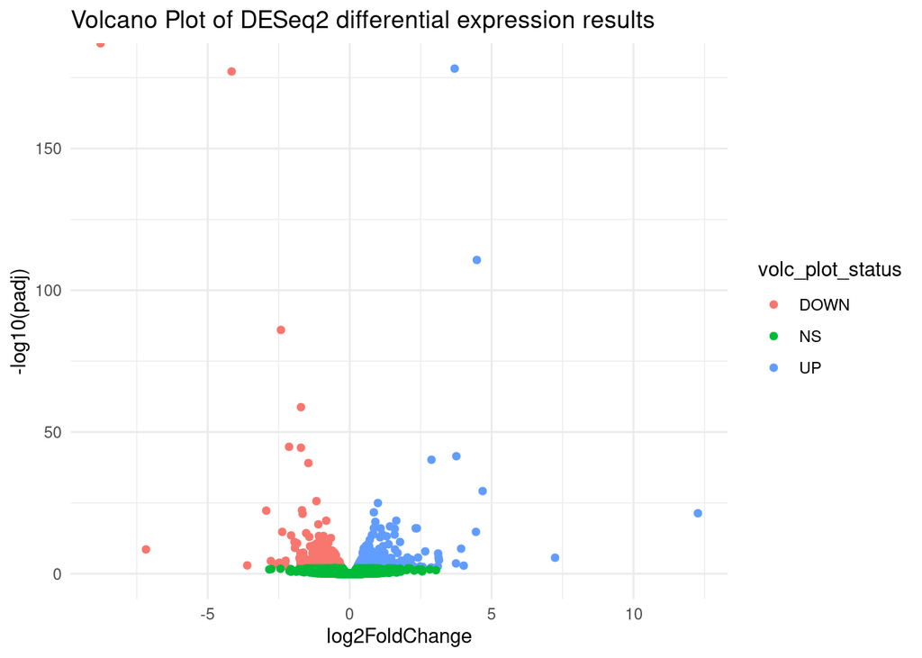

```r
ggplot(labeled_res, aes(x=log2FoldChange,y=-log10(padj), color = volc_plot_status)) +
    geom_point() +
    labs(title="Volcano Plot of DESeq2 differential expression results")+
    theme_minimal()
```

[figure not shown]

```r
top_pathways <- function(fgsea_results, num_paths){
  top_paths_pos <- fgsea_results %>%
    filter(NES > 0) %>%
    arrange(padj) %>%
    slice_head(n = num_paths)

  top_paths_neg <- fgsea_results %>%
    filter(NES < 0) %>%
    arrange(padj) %>%
    slice_head(n = num_paths)

  # Combine the two sets of pathways
  top_paths <- bind_rows(top_paths_pos, top_paths_neg) %>%
    mutate(
      Pathway = str_replace_all(pathway, "_", " ") %>% str_wrap(),
      Direction = ifelse(NES >0, "Positive", "Negative")
    )

  # Plot the bar chart
barchart <- ggplot(top_paths, aes(x = reorder(Pathway, NES), y = NES, fill = NES > 0)) +
  geom_col() +
  scale_fill_manual(values = c("blue", "red"), labels = c("Negative NES", "Positive NES")) +
  labs(title = "fgsea reults for Hallmark MSigDB gene set", y = "Normalized Enrichment Score (NES)", x= NULL) +
  theme_minimal(base_size =12) +
  theme(axis.text.y = element_text(size =7),
        plot.title = element_text(size=8),
        axis.title.x = element_text(size = 6)) + coord_flip()+
  guides(fill = "none")

    return(barchart)
}

top_pathways(filtered_fgsea, 10)
```

### Methods

The FASTQ files from the sequencing experiment conducted by Chandra et al. were first assessed for quality using FASTQC (v0.12.1). STAR (v2.7.11b) was used to generate a genome index for the human reference genome and to align the sequencing reads to the reference. The quality of the raw and aligned reads was further evaluated using MultiQC (v1.25).

DESeq2 was used to identify differentially expressed genes, with significance determined at a false discovery rate (FDR) threshold of p-adjusted < 0.05. Principal component analysis (PCA) and a sample distance matrix were used to explore overall expression patterns and sample relationships.

For functional analysis, gene set enrichment was performed using the EnrichR package with the Reactome database. Additionally, FGSEA was applied to assess pathway enrichment based on gene-level ranking.

#### Differences in Methods

In my methods we did not trim adapter sequences or low quality reads and in the publication the authors used Cutadapt to remove adapter sequences. Not trimming adapters could have lead to the inclusion of some lower quality bases. The authors also used an older version of STAR which could lead to some alignment differences.

In our methods we used VERSE for gene level counting compared to featureCounts being used by the authors of the publication. They also had a higher filtering threshold. <50 reads across all sampes. This could have introduced some noise to my results. They also used Fdrtool and stricted FDR threshold of 0.01.

Finally we used different enrichment analysis tools which may lead to variation in detected pathways.

## Discussion Questions

### RNAseq

1. List the major high-level steps of a basic RNAseq experiment to look for differentially expressed genes. At each step, list what data you need to perform each step and what format they are in (if applicable). At minimum, there are 4 essential steps.

The starting point of a basic RNA-seq experiment are the sequencing reads in .fastq format. The first step is to perform sample quality control with FastQC. The second step is align the reads to the reference genome using a splice-aware aligner like STAR. For this step the input is the fastq reads and the output is a bam file. The third step is post alignment quality control the input for which is the bam file. The fourth major step is the quantification of alignments for which the bam and gtf files are needed. This is followed by filtering, normalization, and analysis of the counts for which the counts csv is needed.

2a. What aspect of the data does this plot show?

This plot shows the distribution of the GC content across all the sequences in a sequencing experiment.

2b. Make an interpretation of this plot assuming the data type was RNASeq.

The GC distribution is expected to follow a normal distribution but peaks in the distribution could indicate over-represented sequences.

2c. Do you think this plot indicates there was a problem with the dataset? Explain your answer.

The second peak suggests an overrepresentation of certain GC-rich sequences. This could be due to adapter contamination, rRNA contamination, or PCR amplification bias. Further investigation is needed to determine the cause.

2d. Make a hypothesis about what the problem represents. Outline a bioinformatics strategy that would enable you to confirm your hypothesis.

In this case it is possible that the second peak indicates the presence of adapter sequences that need to be trimmed. You can see which sequences are overrepresented and creating the second peak. If these are indeed adapter sequences - they can be trimmed off using a software like trimmomatic. If these are rRNA sequences you could parse the reads and filter for GC high sequences. After pulling out these sequences you can BLAST these to confirm if these are rRNA contamination. Could also align the reads to rRNA sequences. 3. What is a splice-aware aligner? When is it important to use a splice-aware aligner?

A splice-aware aligner (STAR, HISAT2) recognizes exon-intron boundaries and correctly maps reads spanning splice junctions. This is essential for RNA-seq because many reads come from spliced mRNA. Without a splice-aware aligner, reads spanning exon-exon junctions may be discarded or incorrectly mapped.

4. What does a “gene-level” count as produced by VERSE or any other counting tool in a RNAseq experiment represent?

A gene-level count represents the number of reads that align to a given gene’s exons. The sum of the union of all a genes exon counts. These counts are used to estimate gene expression but must be normalized to account for gene length and sequencing depth.

5. In your own words, briefly describe what information the matching GTF for a reference genome stores. A GTF (Gene Transfer Format) file stores gene annotations, including genomic coordinates of genes, transcripts, exons, coding sequences (CDS), UTRs, and other regulatory elements.
6. When counting alignments using VERSE or any other utility, why do we need to provide the matching reference genome GTF file?

We need the GTF file because the alignments contain sequencing reads that need to be assigned to the genomic features like genes and exons. These features are necessary for read assignment.

Assume the following result is statistically significant with a positive NES (normalized enrichment score) and that it represents a GSEA experiment performed on the entire list of genes discovered in the experiment ranked by log2FoldChange (i.e. genes that are “upregulated” in the cells treated with drug are on the “left” and genes that are “downregulated” due to treatment are on the “right”).

7a. Form a valid interpretation / conclusion of the results shown in the plot given the above setup.

There is an enrichment of genes in the acute inflammatory response gene set in our differential expression results. These genes are upregulated in our experimental condition compared to the control. This suggests that the inflammatory response is involved in the drugs activity.

7b. Now consider that all of the genes driving the enrichment are all activators of the inflammatory pathway. Does your interpretation change and if so, how?

Yes, this provides more context suggesting that the drug elicits an inflammatory response in the cells.

7c. Finally, consider that all of the genes driving the enrichment all function to inhibit inflammation. Does your interpretation change and if so, how?

Yes, this suggests the opposite drug mechanism that the drug suppresses inflammatory response in the cells.

8. Rank the following quality control metrics for a 2x100nt paired-end illumina mRNAseq dataset from most concerning to least concerning. Provide a brief statement on where you ranked each and why. Assume that the data has not been processed and was provided as-is from the sequencing machine.
- Unequal Read Lengths (highly concerning could be due to sequencing errors - after sequencing all reads should be about the same length)
- Unequal number of forward and reverse reads (highly concerning can indicate sample preparation or sequencing issues)
- 50% of reads are multimapped after alignment to the appropriate genome (suggests poor genome annotation or poor quality sequencing)
- Nucleotide frequencies of ACTG are not equal over the entire read (depending on where this is could be concerning)
- 15% of reads have identical sequences (high levels of duplicates can happen with highly expressed genes)
- Average PHRED score < 20 in the last 10 bases (mildly concerning because the poor base quality could lead to misalignment but this is at the edges can be addressed)
- 10% of reads are unmapped after alignment to the appropriate genome (10% is not that high so this is not concerning at all)
- Non-random nucleotide distribution in the first 6 bases (this is not really concerning it is edge effect)